# World Life Expectancy Scatterplot from Reshaped Data

Andrew Heneghan

2/28/2024

# 1 Reading In and Reshaping the Data Sets

```r
inc.per.person <- read.csv(file="https://raw.githubusercontent.com/azheneghan/aheneghan/main/datasets/income_per_person.csv")
inc.pp.long <- inc.per.person %>%
  pivot_longer(cols = X1800:X2018, names_to = "year", names_prefix = "X", values_to = "income") %>%
  dplyr::rename(country = geo) %>%
  mutate(newKey = paste(country, "-", year, sep = ""))
life.exp.yrs <- read.csv(file="https://raw.githubusercontent.com/azheneghan/aheneghan/main/datasets/life_expectancy_years.csv")
life.exp.long <- life.exp.yrs %>%
  pivot_longer(cols = X1800:X2018, names_to = "year", names_prefix = "X", values_to = "life.expectancy") %>%
  dplyr::rename(country = geo) %>%
  mutate(newKey = paste(country, "-", year, sep = ""))
country.region <- read.csv(file="https://raw.githubusercontent.com/azheneghan/aheneghan/main/datasets/countries_total.csv")
pop.size <- read.csv(file="https://raw.githubusercontent.com/azheneghan/aheneghan/main/datasets/population_total.csv")
pop.size.long <- pop.size %>%
  pivot_longer(cols = X1800:X2018, names_to = "year", names_prefix = "X", values_to = "population.size") %>%
  dplyr::rename(country = geo) %>%
  mutate(newKey = paste(country, "-", year, sep = ""))
```

In order to be able to merge the four datasets together, three of them, Income per Person, Life Expectancy in Years, and Population Size, had to be reshaped first, from wide to longitudinal. The country region dataset was already longitudinal. By doing so, each of these longitudinal data sets had three variables. All three had country and year, while the third variable in each attributed to the variable focused on in that dataset, as stated by the titles. The numerical values of the wide datasets acted as the values for the unique variable column in each. These four longitudinal datasets were then read into R Studio.

# 2 Merging the Data Into One

```r
LifeExpIncom <- merge(x = inc.pp.long, y = life.exp.long, by.x = 'newKey', by.y ='newKey', all = FALSE)
LifeExpIncom <- LifeExpIncom %>%
  dplyr::select(newKey, country.x, year.x, income, life.expectancy) %>%
  dplyr::rename(country = country.x, year = year.x)
LifeExpIncom <- merge(x = LifeExpIncom, y = country.region, by.x = 'country', by.y ='name', all.x = TRUE)
LifeExpIncom <- merge(x = LifeExpIncom, y = pop.size.long, by.x = 'newKey', by.y ='newKey', all = FALSE)
LifeExpIncom <- LifeExpIncom %>%
  dplyr::select(-newKey, -country.y, -year.y) %>%
  dplyr::rename(country = country.x, year = year.x)
#write.csv(x = LifeExpIncom, file = "LifeExpIncom.csv", row.names = FALSE)
LifeExpIncom <- read.csv(file = "https://raw.githubusercontent.com/azheneghan/aheneghan/main/datasets/LifeExpIncom.csv")
```

With the datasets all reshaped to be longitudinal, it was time to start merging them together. First, the Income per Person and Life Expectancy datasets were merged with an inner join using the country and year variables to create a dataset called LifeExpIncom. It contains four variables: country, year, income, and life expectancy (in years). This dataset was then merged with the country region dataset using a left join and the population size dataset using another inner join. The final merged dataset, LifeExpIncom, contains 15 variables, including income, life expectancy, population size, and country region. There are 40,953 country observations in all, but some of these do contain missing values since the separate four datasets had different observations. This dataset was uploaded to the GitHub repository and read in from there for creating the scatterplot.

# 3 Data Subset and Scatterplot

```r
data2000 <- LifeExpIncom %>%
  filter(year == "2000")
```

For the ggplot() scatterplot, a subset of the merged data was created to only include observations from the year 2000.

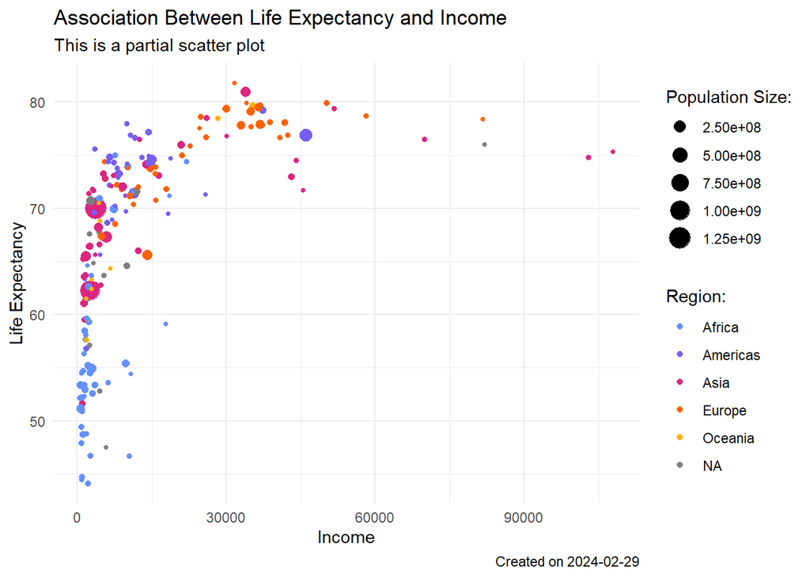

```r
cols1 = c("#648FFF","#785EF0","#DC267F","#FE6100","#FFB000","#882255")
ggplot(data = data2000, mapping = aes(x = income, y = life.expectancy, color = region, size = population.size)) + geom_point() + labs(
                 x = "Income",
                 y = "Life Expectancy",
                 size = "Population Size:",
                 color = "Region:",
                 title = "Association Between Life Expectancy and Income",
                 subtitle = "This is a partial scatter plot",
                 caption = paste("Created on", Sys.Date())) + scale_color_manual(values = cols1) + theme_minimal()
```

This scatterplot uses income and life expectancy of each country during the year of 2000 as the two variables defining the axes. Therefore, they will be the variables to be compared. The size of each point represents that country’s population size during the year 2000. The color of each point represents the region or continent in which each country resides. During the year 2000, it seemed many countries have low income, especially those in Africa. Most African countries also had the lowest life expectancies. Those with larger incomes tended to be in Asia and Europe, with few in the Americas as well. Overall, it seemed like over half the countries had low incomes below $30,000. The common pattern here is that life expectancy tended to increase only if income increased as well. This demonstrates that countries, and those who live in them, need a relatively large yearly income and number of resources in order for those living in these countries to live longer lives. Unfortunately, that is the opposite case with Africa, who tend to have countries with low income and, therefore, lower life expectancies.